# Имитационное моделирование

Лабораторная работа №3. Агентная модель Daisyworld

Исаева Зарина Исмайилбековна

Российский университет дружбы народов имени Патриса Лумумбы

2026-09-05

# 1 Информация

## 1.1 Докладчик

- Исаева Зарина Исмайилбековна
- Студентка
- Российский университет дружбы народов имени Патриса Лумумбы
- Студенческий билет: 1132232882

# 2 Цель и задачи

## 2.1 Цель работы

- построить агентную модель Daisyworld на периодической клеточной сетке
- исследовать связь популяций, альбедо и температуры
- выполнить базовые и параметрические сценарии
- подготовить воспроизводимые JL, IPYNB, QMD и HTML

## 2.2 Состав задания

| Группа | Сценарии |
| --- | --- |
| пространственная визуализация | 2 |
| численность популяций | 2 |
| динамика светимости | 2 |
| анимация | 1 |
| **Всего** | **7** |

- параметрический план содержит четыре сочетания условий
- каждый notebook выполнен с сохранёнными результатами

# 3 Агентная модель

## 3.1 Агенты и среда

**Агент Daisy**

- вид: чёрный или белый
- возраст
- альбедо
- одна занятая клетка

**Среда**

- решётка $30\times30$
- периодические границы
- поле локальной температуры

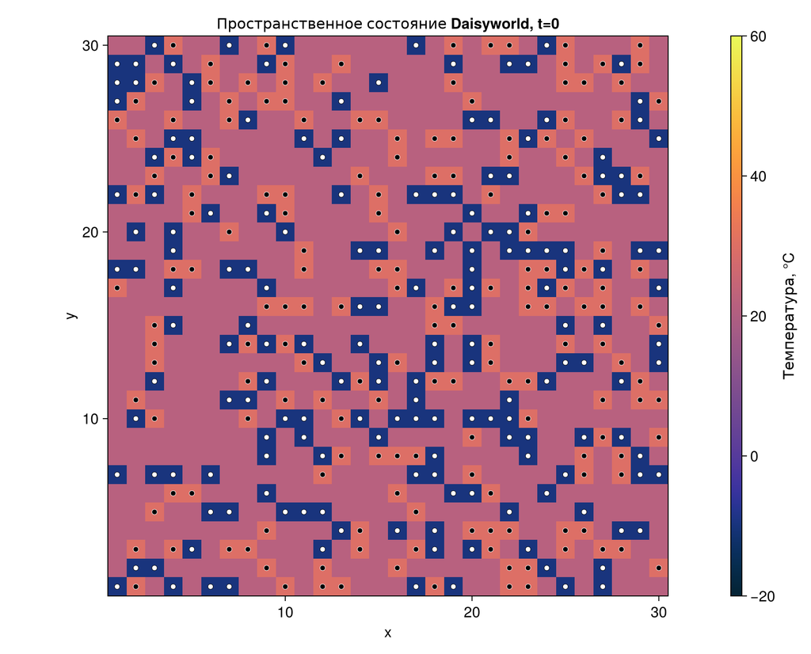

## 3.2 Локальные правила

1. клетка нагревается с учётом альбедо
2. температура диффундирует по восьми соседям
3. растение пытается заселить свободную соседнюю клетку
4. возраст увеличивается, старые агенты удаляются
5. светимость меняется по выбранному сценарию

## 3.3 Температура клетки

$$Q=(1-A)L,\qquad T_{local}=72\ln Q+80.$$

- малое альбедо увеличивает поглощение
- чёрные маргаритки нагревают клетку сильнее
- белые маргаритки отражают большую долю излучения
- синхронная диффузия не зависит от порядка обхода сетки

## 3.4 Вероятность размножения

$$p(T)=\max\left(0,\min\left(1,\,
0{,}1457T-0{,}0032T^2-0{,}6443\right)\right)$$

- вероятность ограничена диапазоном от 0 до 1
- размножение возможно только в благоприятной области
- вид потомка совпадает с видом родительского агента

# 4 Реализация

## 4.1 Структура проекта

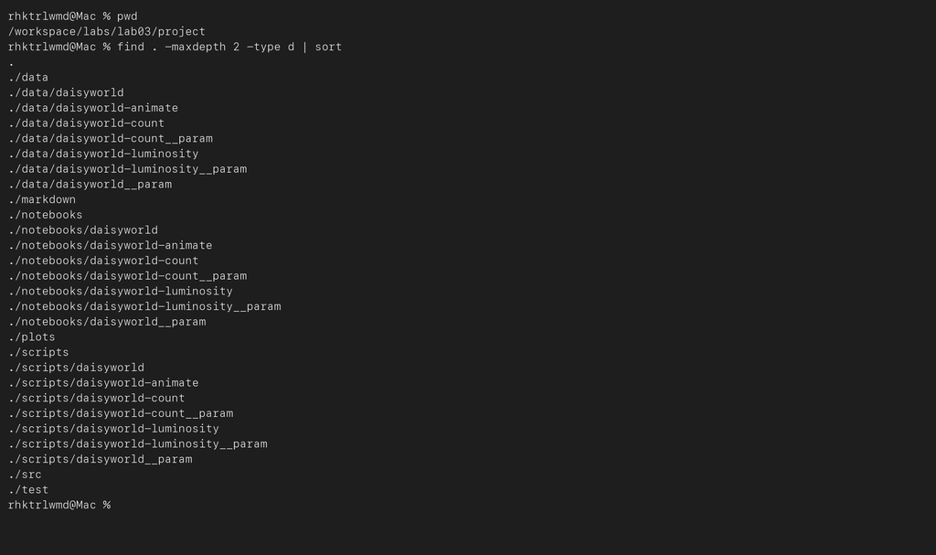

- модуль модели отделён от семи сценариев
- таблицы, графики и производные форматы сгруппированы по опыту

## 4.2 Общий модуль

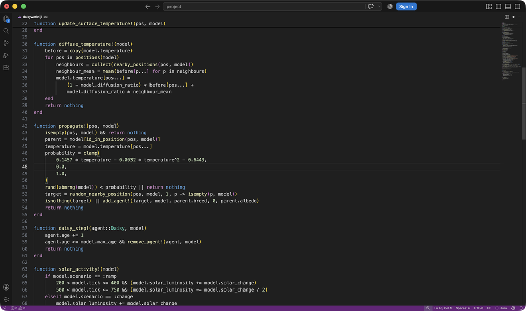

- проверка всех диапазонов параметров
- воспроизводимый генератор MersenneTwister
- единая функция наблюдения для всех экспериментов

## 4.3 Базовые параметры

| Параметр | Значение |
| --- | --- |
| размер сетки | $30\times30$ |
| max_age | 25 |
| init_white, init_black | 0,2; 0,2 |
| albedo_white, albedo_black | 0,75; 0,25 |
| surface_albedo | 0,4 |
| diffusion_ratio | 0,5 |
| seed | 165 |

# 5 Пространственная эволюция

## 5.1 Начальное состояние

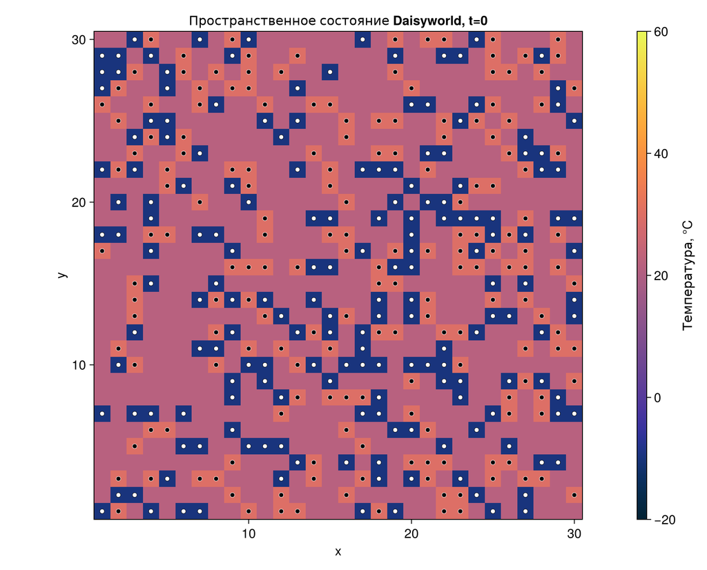

| Чёрные | Белые | Свободные | Температура |
| --- | --- | --- | --- |
| 180 | 180 | 540 | 16,91 °C |

## 5.2 Быстрое заполнение сетки

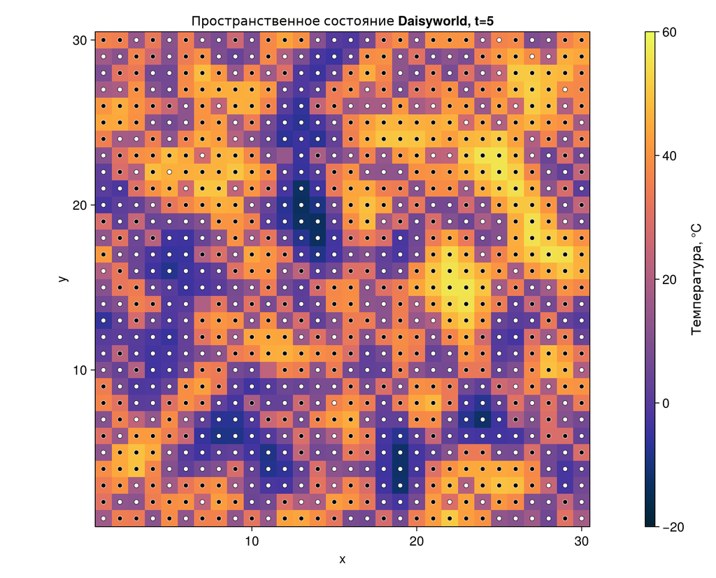

| Чёрные | Белые | Свободные | Температура |
| --- | --- | --- | --- |
| 457 | 440 | 3 | 23,03 °C |

## 5.3 Состояние на шаге 45

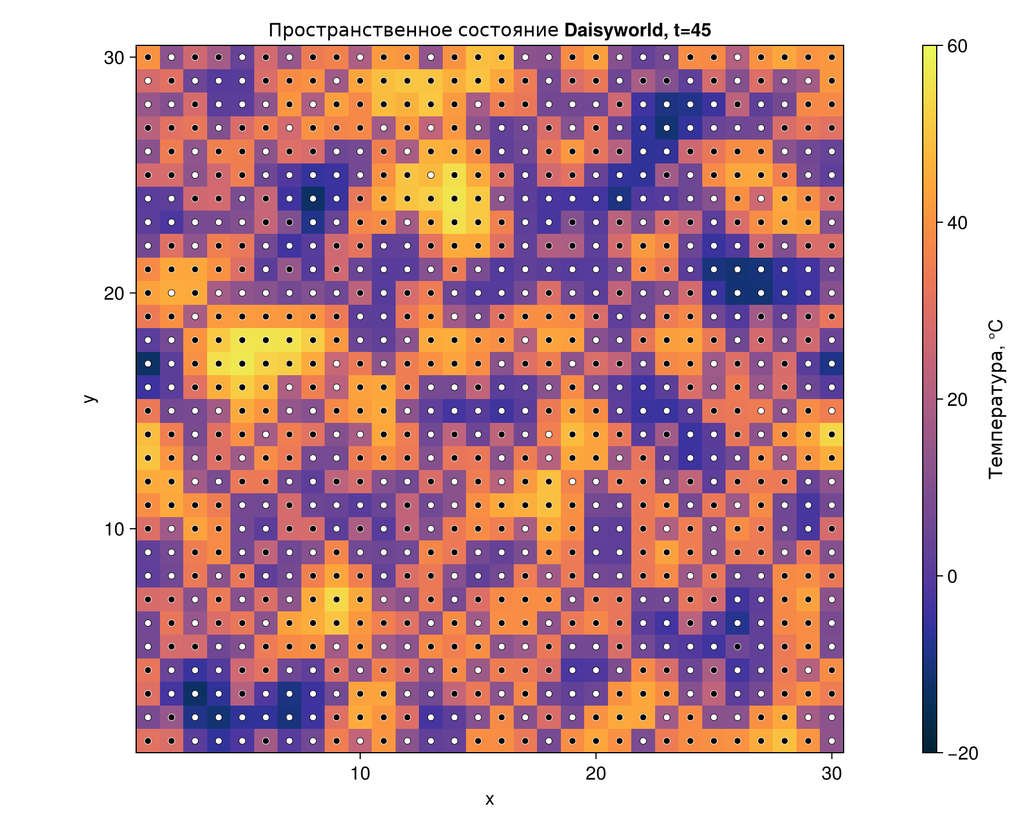

| Чёрные | Белые | Свободные | Температура |
| --- | --- | --- | --- |
| 469 | 431 | 0 | 21,70 °C |

## 5.4 Анимация

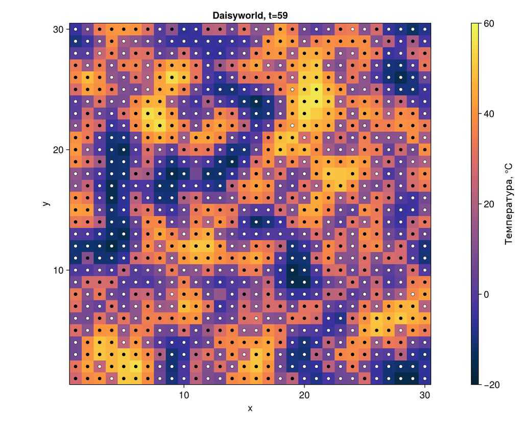

- 60 последовательных состояний
- частота 10 кадров/с
- MP4 длительностью 6 секунд
- отдельный CSV из 60 наблюдений
- фиксированный seed

# 6 Динамика популяций

## 6.1 Базовая численность

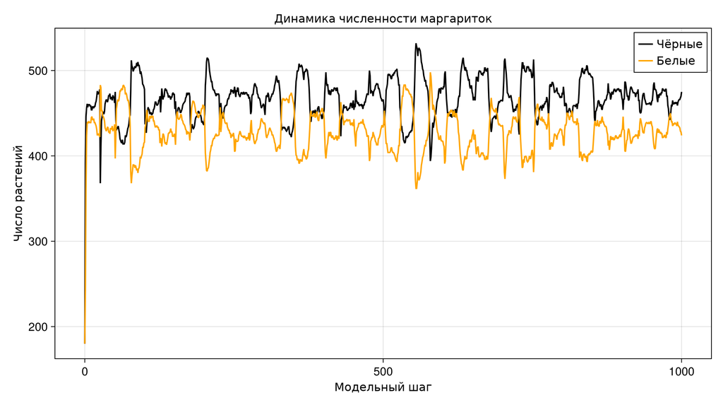

- оба вида сохраняются на всём горизонте
- к шагу 1000: 475 чёрных и 424 белые
- максимумы: 532 и 498 растений

## 6.2 Светимость ramp

[figure not shown]

- рост $L$: шаги 201–400
- плато $L=2$: шаги 401–500
- снижение: шаги 501–750
- окончательное значение $L=1{,}375$

## 6.3 Связанная динамика

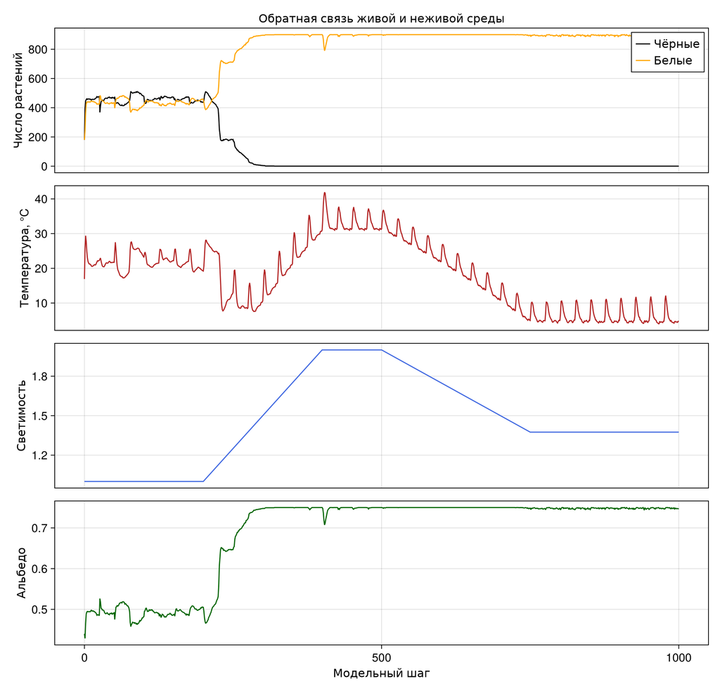

- рост светимости вызывает замещение чёрных растений белыми
- к шагу 400 все клетки заняты белыми маргаритками

## 6.4 Биотический и абиотический мир

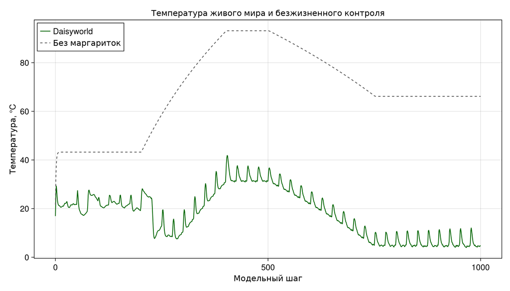

- при $L=2$ контроль без растений достигает 93,13 °C
- Daisyworld удерживает 31,35 °C
- максимальное уменьшение отклонения: 62,32 °C

## 6.5 Предел саморегуляции

| Шаг | Светимость | Чёрные | Белые | Температура |
| --- | --- | --- | --- | --- |
| 200 | 1,000 | 438 | 458 | 19,21 °C |
| 400 | 2,000 | 0 | 900 | 31,03 °C |
| 500 | 2,000 | 0 | 900 | 31,35 °C |
| 750 | 1,375 | 0 | 896 | 4,95 °C |
| 1000 | 1,375 | 0 | 894 | 4,79 °C |

- после быстрого снижения светимости состав популяции перестраивается медленно

# 7 Параметрическое исследование

## 7.1 План эксперимента

| Опыт | max_age | init_white | init_black |
| --- | --- | --- | --- |
| 1 | 25 | 0,2 | 0,2 |
| 2 | 25 | 0,8 | 0,2 |
| 3 | 40 | 0,2 | 0,2 |
| 4 | 40 | 0,8 | 0,2 |

- каждый опыт повторён для пространственного, численного и светового сценария

## 7.2 Пространственные состояния

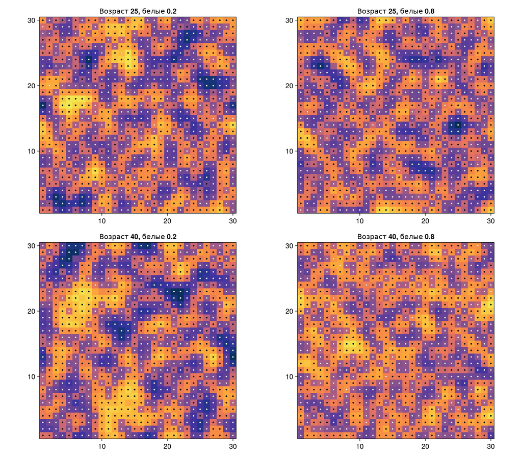

- сравниваются четыре состояния на шаге 45
- увеличение возраста уменьшает частоту освобождения клеток

## 7.3 Численность при разных параметрах

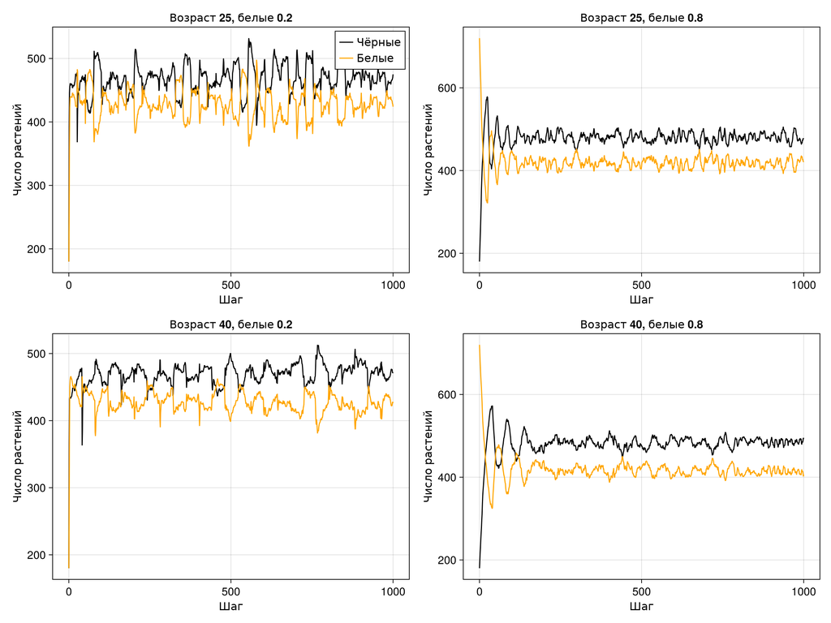

- ни одна популяция не вымерла
- все траектории содержат 1001 сохранённое состояние

## 7.4 Ошибка регулирования

| max_age | init_white | Средняя ошибка |
| --- | --- | --- |
| 25 | 0,2 | 1,679 °C |
| 25 | 0,8 | 1,374 °C |
| 40 | 0,2 | **1,200 °C** |
| 40 | 0,8 | 1,500 °C |

- лучший результат базовой светимости: возраст 40 и начальная доля белых 0,2

## 7.5 Температура в сценарии ramp

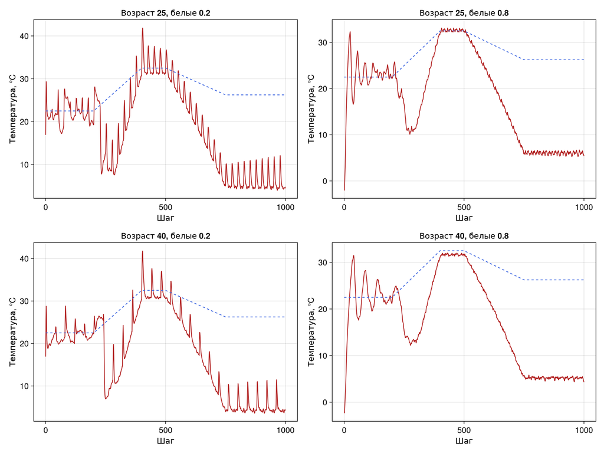

- максимум находится в диапазоне 32,04–41,91 °C
- большая начальная доля белых ограничивает верхний температурный максимум

# 8 Воспроизводимость

## 8.1 Литературный процесс

1. один комментированный JL служит первичным исходником
2. Literate формирует чистый JL, QMD и IPYNB
3. notebook выполняется в окружении проекта
4. Quarto собирает самостоятельный HTML
5. QMD-фрагмент целиком включается в отчёт

## 8.2 Выполненные notebooks

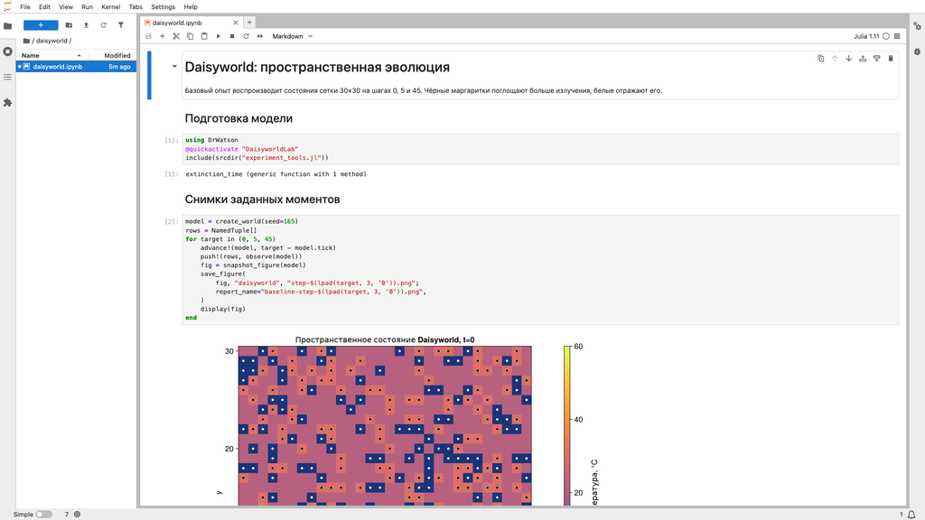

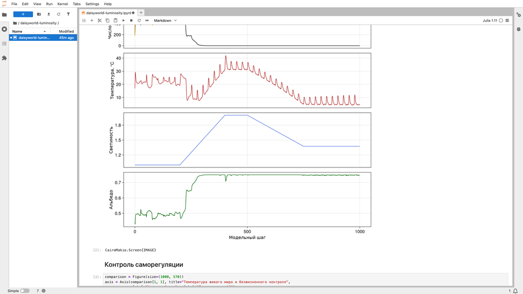

- сохранены номера выполнения, таблицы и встроенные графики

## 8.3 Параметрический notebook

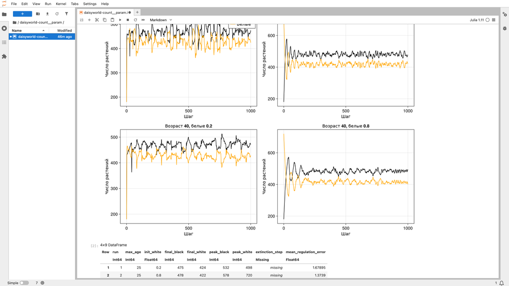

- показаны все четыре сочетания условий
- результат получен из того же литературного источника

# 9 Проверка

## 9.1 Автоматические тесты

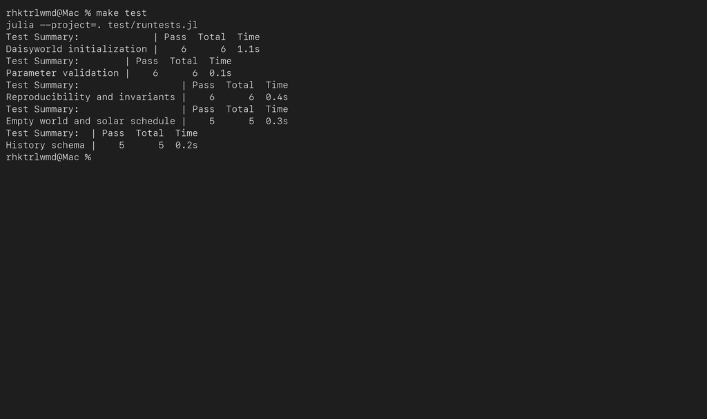

- 28 проверок завершены успешно
- проверены ограничения, воспроизводимость и баланс клеток
- отдельно проверен точный график изменения светимости

## 9.2 Полнота производных форматов

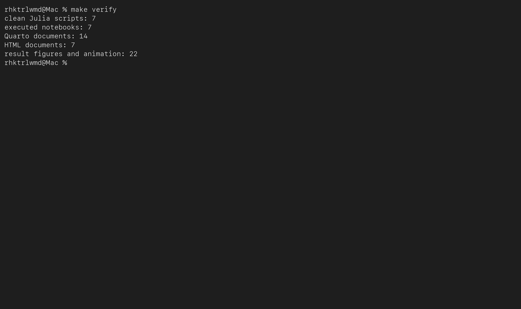

[output not shown]

# 10 Выводы

## 10.1 Основные результаты

- выполнены все семь сценариев главы 3
- подтверждена локальная температурная обратная связь
- в постоянных условиях оба вида сохраняются 1000 шагов
- биота сильно уменьшает перегрев относительно контроля
- быстрый спад светимости выявляет предел адаптации
- полный проект воспроизводится командами Makefile
- безжизненный контроль отделяет действие биоты от внешнего нагрева